# 03b. Dialogues on Democracy: Method Checks (Attrition, Speeders, Conversation Detail, Power)

Shaye

2026-10-27

# Set Up

## Differential Attrition

```r
df_all$messageType <- factor(df_all$messageType)
df_all$ConditionFeedback <- factor(df_all$ConditionFeedback)
df_all$ConditionChat <- factor(df_all$ConditionChat)


da.all.s1 <- df_all %>% filter(ScreenedDummy == 0, Study == 1)
da.all.s2 <- df_all %>% filter(ScreenedDummy == 0,Study == 2)

da.s1$messageType = relevel(da.s1$messageType,ref="Qualtrics  + Adversarial Dialogue")
da.s2$ConditionFeedback = relevel(da.s2$ConditionFeedback,ref="Control")



#summaries

table(da.s1$AttritDurExp, da.s1$messageType)
```

```
##
##     Qualtrics  + Adversarial Dialogue Qualtrics + Belief-Tailored
##   0                               190                         210
##   1                                 7                          13
##
##     Qualtrics + Belief & Values-Tailored Chat + Adversarial Dialogue
##   0                                  196                         217
##   1                                   15                          16
##
##     Chat + Control Chat + Belief-Tailored Chat Chat + Belief & Values-Tailored
##   0              0                    175    0                             202
##   1              0                     31    0                              29
##
##     Personalized-Chat
##   0                 0
##   1                 0
```

```r
nice_table(as.data.frame(prop.table(table(da.s1$AttritDurExp, da.s1$messageType),margin = 2)*100) %>%
             filter(Var1 == 1, Var2 != "Chat + Control") %>%
             select(-(Var1)) %>%
  dplyr::rename(Condition = Var2,
                "Attrition Rate" = Freq))
```

| Condition | Attrition Rate |
| --- | --- |
| Qualtrics + Adversarial Dialogue | 3.55 |
| Qualtrics + Belief-Tailored | 5.83 |
| Qualtrics + Belief & Values-Tailored | 7.11 |
| Chat + Adversarial Dialogue | 6.87 |
| Chat + Belief-Tailored | 15.05 |
| Chat |  |
| Chat + Belief & Values-Tailored | 12.55 |
| Personalized-Chat |  |

```r
table(da.s2$AttritDurExp, da.s2$ConditionFeedback)
```

```
##
##     Control Adversarial Dialogue Belief & Values-Tailored Belief-Tailored
##   0     200                  177                        0             208
##   1      35                   25                        0              34
```

```r
nice_table(as.data.frame(prop.table(table(da.s2$AttritDurExp, da.s2$ConditionFeedback),margin = 2)*100) %>%
             filter(Var1 == 1, Var2 != "Belief & Values-Tailored") %>%
             select(-(Var1)) %>%
  dplyr::rename(Condition = Var2,
                "Attrition Rate" = Freq))
```

| Condition | Attrition Rate |
| --- | --- |
| Control | 14.89 |
| Adversarial Dialogue | 12.38 |
| Belief-Tailored | 14.05 |

```r
table(df_all$AttritDurExp,useNA = "always")
```

```
##
##    0    1 <NA>
## 4140  443 4398
```

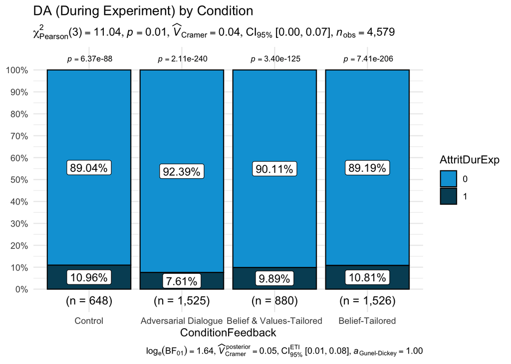

```r
ggbarstats(
  data = df_all,
  y = ConditionFeedback,
  x = AttritDurExp,
  k = 3,
  perc.k = 2,
  digits.perc = 2,
  p.digits = 3,
  title = "DA (During Experiment) by Condition"
) +
  scale_fill_economist() +
  theme_minimal()
```

```r
table(da.s1$AttritDurExp)
```

```
##
##    0    1
## 1190  112
```

```r
table(da.all.s2$Screened)
```

```
##
## Not Screened
##         1530
```

```r
table(da.s2$AttritDurExp)
```

```
##
##   0   1
## 585  96
```

```r
table(da.s1$Drop)
```

```
##
##            CC >= 50                Keep Non-Election Denier
##                  26                1215                  62
```

```r
table(da.s1$Drop,da.s1$AttritDurExp)
```

```
##
##                          0    1
##   CC >= 50              23    3
##   Keep                1115  100
##   Non-Election Denier   52    9
```

```r
table(da.s2$Drop)
```

```
##
##            CC >= 50                Keep Non-Election Denier
##                   9                 633                  39
```

```r
table(da.s2$Drop,da.s2$AttritDurExp)
```

```
##
##                         0   1
##   CC >= 50              7   2
##   Keep                545  88
##   Non-Election Denier  33   6
```

```r
prop.table(table(da.s1$AttritDurExp))*100
```

```
##
##         0         1
## 91.397849  8.602151
```

```r
table(da.s1$messageType,da.s1$AttritDurExp)
```

```
##
##                                          0   1
##   Qualtrics  + Adversarial Dialogue    190   7
##   Qualtrics + Belief-Tailored          210  13
##   Qualtrics + Belief & Values-Tailored 196  15
##   Chat + Adversarial Dialogue          217  16
##   Chat + Control                         0   0
##   Chat + Belief-Tailored               175  31
##   Chat                                   0   0
##   Chat + Belief & Values-Tailored      202  29
##   Personalized-Chat                      0   0
```

```r
table(is.na(da.s1$Condition))
```

```
##
## FALSE  TRUE
##  1301     6
```

```r
table(is.na(da.s1$Random))
```

```
##
## FALSE  TRUE
##  1187   120
```

```r
table(da.s2$ConditionFeedback,da.s2$AttritDurExp)
```

```
##
##                              0   1
##   Control                  200  35
##   Adversarial Dialogue     177  25
##   Belief & Values-Tailored   0   0
##   Belief-Tailored          208  34
```

```r
##overall DA----
    #chi square version

report(chisq.test(da.s1$AttritDurExp,da.s1$messageType)) #full condition attrition
```

```
## Effect sizes were labelled following Funder's (2019) recommendations.
##
## The Pearson's Chi-squared test of independence between da.s1$AttritDurExp and
## da.s1$messageType suggests that the effect is statistically significant, and
## small (chi2 = 25.72, p < .001; Adjusted Cramer's v = 0.13, 95% CI [0.05, 1.00])
```

```r
report(chisq.test(da.s1$AttritDurExp,da.s1$ConditionChat))
```

```
## Effect sizes were labelled following Funder's (2019) recommendations.
##
## The Pearson's Chi-squared test with Yates' continuity correction of
## independence between da.s1$AttritDurExp and da.s1$ConditionChat suggests that
## the effect is statistically significant, and very small (chi2 = 13.26, p <
## .001; Adjusted Cramer's v = 0.10, 95% CI [0.05, 1.00])
```

```r
report(chisq.test(da.s1$AttritDurExp,da.s1$ConditionFeedback))
```

```
## Effect sizes were labelled following Funder's (2019) recommendations.
##
## The Pearson's Chi-squared test of independence between da.s1$AttritDurExp and
## da.s1$ConditionFeedback suggests that the effect is statistically significant,
## and very small (chi2 = 8.36, p = 0.015; Adjusted Cramer's v = 0.07, 95% CI
## [0.00, 1.00])
```

```r
report(chisq.test(da.s2$AttritDurExp,da.s2$ConditionFeedback))
```

```
## Effect sizes were labelled following Funder's (2019) recommendations.
##
## The Pearson's Chi-squared test of independence between da.s2$AttritDurExp and
## da.s2$ConditionFeedback suggests that the effect is statistically not
## significant, and tiny (chi2 = 0.59, p = 0.744; Adjusted Cramer's v = 0.00, 95%
## CI [0.00, 1.00])
```

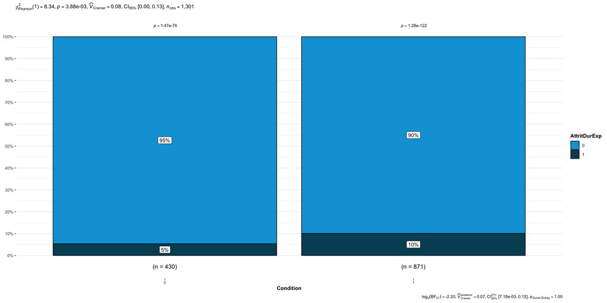

```r
fig.da <- ggbarstats(
  data = da.s1,
  y = Condition,
  x = AttritDurExp)+
  scale_fill_economist()
fig.da
```

```r
extract_stats(fig.da)
```

```
## $subtitle_data
## # A tibble: 1 × 13
##   statistic    df p.value method                     effectsize        estimate
##       <dbl> <int>   <dbl> <chr>                      <chr>                <dbl>
## 1      8.34     1 0.00388 Pearson's Chi-squared test Cramer's V (adj.)   0.0751
##   conf.level conf.low conf.high conf.method conf.distribution n.obs expression
##        <dbl>    <dbl>     <dbl> <chr>       <chr>             <int> <list>
## 1       0.95        0     0.132 ncp         chisq              1301 <language>
##
## $caption_data
## # A tibble: 1 × 15
##   term  conf.level effectsize estimate conf.low conf.high
##   <chr>      <dbl> <chr>         <dbl>    <dbl>     <dbl>
## 1 Ratio       0.95 Cramers_v    0.0732  0.00718     0.121
##   prior.distribution      prior.location prior.scale  bf10
##   <chr>                            <dbl>       <dbl> <dbl>
## 1 independent multinomial              0           1  9.02
##   method                              conf.method log_e_bf10 n.obs expression
##   <chr>                               <chr>            <dbl> <int> <list>
## 1 Bayesian contingency table analysis ETI               2.20  1301 <language>
##
## $pairwise_comparisons_data
## NULL
##
## $descriptive_data
## # A tibble: 4 × 5
##   Condition AttritDurExp counts  perc .label
##   <fct>     <fct>         <int> <dbl> <chr>
## 1 0         0               407 94.7  95%
## 2 0         1                23  5.35 5%
## 3 1         0               783 89.9  90%
## 4 1         1                88 10.1  10%
##
## $one_sample_data
## # A tibble: 2 × 19
##   Condition counts  perc N         statistic    df   p.value method   effectsize
##   <fct>      <int> <dbl> <chr>         <dbl> <dbl>     <dbl> <chr>    <chr>
## 1 1            871  66.9 (n = 871)      555.     1 1.28e-122 Chi-squ… Pearson's…
## 2 0            430  33.1 (n = 430)      343.     1 1.47e- 76 Chi-squ… Pearson's…
## # ℹ 10 more variables: estimate <dbl>, conf.level <dbl>, conf.low <dbl>,
## #   conf.high <dbl>, conf.method <chr>, conf.distribution <chr>, n.obs <int>,
## #   expression <list>, .label <glue>, .p.label <glue>
##
## $tidy_data
## NULL
##
## $glance_data
## NULL
##
## attr(,"class")
## [1] "ggstatsplot_stats" "list"
```

```r
#DA - s1----

# Differential Attrition by Condition (Logistic Regression)
res_da_s1 <- clean_regress(
  da.s1,
  dvs = "AttritDurExp",
  type = "logistic",
  predictors = ~ messageType,
  dv_labels = c(AttritDurExp = "Study 1 Attrition")
)
cr_table(res_da_s1, style = "stargazer")
```

|  | Study 1 Attrition Logistic OR |
| --- | --- |
| Intercept | 0.04*** |
|  | (0.01) |
| Message type |  |
| Qualtrics + adversarial dialogue (ref.) | — |
| Qualtrics + belief tailored | 1.68 |
|  | (0.81) |
| Qualtrics + belief & values tailored | 2.08 |
|  | (0.98) |
| Chat + adversarial dialogue | 2.00 |
|  | (0.93) |
| Chat + control |  |
| Chat + belief tailored | 4.81*** |
|  | (2.08) |
| Chat |  |
| Chat + belief & values tailored | 3.90** |
|  | (1.69) |
| Personalized chat |  |
| Model fit |  |
| Observations | 1,301 |
| Tjur R² | 0.02 |
| AIC | 745.46 |

Note. OR = odds ratio; SE = standard error. SEs and p-values use HC1 robust SEs. Standard errors in parentheses (delta-method SEs for ratios). (ref.) marks the reference category for each factor. * p < .05. ** p < .01. *** p < .001.  
Empty cells: coefficient not estimable in that model (collinear or no observations).

```r
# Differential Attrition with Covariates
res_da2_s1 <- clean_regress(
  da.s1,
  dvs = "AttritDurExp",
  type = "logistic",
  predictors = ~ messageType + Race + Age + GenderClean + Education + DemRep_C.text + religion + VoteMethod.text + AffPol_Pre,
  dv_labels = c(AttritDurExp = "Study 1 Attrition (Covariates)")
)
cr_table(res_da2_s1, style = "stargazer")
```

|  | Study 1 Attrition (Covariates) Logistic OR |
| --- | --- |
| Intercept | 0.06*** |
|  | (0.05) |
| Message type |  |
| Qualtrics + adversarial dialogue (ref.) | — |
| Qualtrics + belief tailored | 1.61 |
|  | (0.87) |
| Qualtrics + belief & values tailored | 2.02 |
|  | (1.04) |
| Chat + adversarial dialogue | 1.90 |
|  | (0.97) |
| Chat + control |  |
| Chat + belief tailored | 4.50** |
|  | (2.18) |
| Chat |  |
| Chat + belief & values tailored | 3.29* |
|  | (1.62) |
| Personalized chat |  |
| Race |  |
| White (ref.) | — |
| Asian | 3.16 |
|  | (1.86) |
| Black | 0.79 |
|  | (0.60) |
| Other | 1.02 |
|  | (0.76) |
| Age | 1.01 |
|  | (0.01) |
| Gender clean |  |
| Female (ref.) | — |
| Male | 0.73 |
|  | (0.17) |
| Other | 1.26 |
|  | (0.97) |
| Education | 0.98 |
|  | (0.07) |
| Dem rep c text |  |
| Lean republican (ref.) | — |
| Republican | 0.93 |
|  | (0.30) |
| Strongly republican | 1.22 |
|  | (0.40) |
| Religion | 0.95 |
|  | (0.06) |
| Vote method text |  |
| In person voting, early (ref.) | — |
| In person voting, election day | 0.80 |
|  | (0.21) |
| Mail in/absentee voting | 0.72 |
|  | (0.24) |
| Other | 0.00*** |
|  | (0.00) |
| Aff pol pre | 1.00 |
|  | (0.00) |
| Model fit |  |
| Observations | 1,115 |
| Tjur R² | 0.03 |
| AIC | 656.52 |

Note. OR = odds ratio; SE = standard error. SEs and p-values use HC1 robust SEs. Standard errors in parentheses (delta-method SEs for ratios). (ref.) marks the reference category for each factor. * p < .05. ** p < .01. *** p < .001.  
Empty cells: coefficient not estimable in that model (collinear or no observations).

```r
##DA by covariate----
# Interaction models between condition and participant characteristics
res_da_int_list <- list(
  Race = clean_regress(da.s1, dvs = "AttritDurExp", type = "logistic", predictors = ~ messageType * Race, dv_labels = c(AttritDurExp = "Attrition x Race")),
  Age = clean_regress(da.s1, dvs = "AttritDurExp", type = "logistic", predictors = ~ messageType * Age, dv_labels = c(AttritDurExp = "Attrition x Age")),
  Gender = clean_regress(da.s1, dvs = "AttritDurExp", type = "logistic", predictors = ~ messageType * GenderClean, dv_labels = c(AttritDurExp = "Attrition x Gender")),
  Education = clean_regress(da.s1, dvs = "AttritDurExp", type = "logistic", predictors = ~ messageType * Education, dv_labels = c(AttritDurExp = "Attrition x Education")),
  DemRep = clean_regress(da.s1, dvs = "AttritDurExp", type = "logistic", predictors = ~ messageType * DemRep_C.text, dv_labels = c(AttritDurExp = "Attrition x Party")),
  Religion = clean_regress(da.s1, dvs = "AttritDurExp", type = "logistic", predictors = ~ messageType * religion, dv_labels = c(AttritDurExp = "Attrition x Religion")),
  VoteMethod = clean_regress(da.s1, dvs = "AttritDurExp", type = "logistic", predictors = ~ messageType * VoteMethod.text, dv_labels = c(AttritDurExp = "Attrition x Vote Method")),
  AffPol = clean_regress(da.s1, dvs = "AttritDurExp", type = "logistic", predictors = ~ messageType * AffPol_Pre, dv_labels = c(AttritDurExp = "Attrition x Baseline AffPol"))
)

# Display each interaction model table using cleanresults stargazer style
purrr::walk(res_da_int_list, ~ print(cr_table(.x, style = "stargazer")))
```

```
## ───────────────────────────────────────────────────────────────────
##                                                Attrition x Race
##                                                    Logistic
##                                                       OR
## ───────────────────────────────────────────────────────────────────
## Intercept                                            0.04***
##                                                      (0.02)
## Message type
##   Qualtrics + adversarial dialogue (ref.)               —
##   Qualtrics + belief tailored                         1.72
##                                                      (0.83)
##   Qualtrics + belief & values tailored                1.92
##                                                      (0.92)
##   Chat + adversarial dialogue                         1.49
##                                                      (0.73)
##   Chat + control
##
##   Chat + belief tailored                             3.69**
##                                                      (1.65)
##   Chat
##
##   Chat + belief & values tailored                     3.05*
##                                                      (1.37)
##   Personalized chat
##
## Race
##   White (ref.)                                          —
##   Asian                                              0.00***
##                                                      (0.00)
##   Black                                              0.00***
##                                                      (0.00)
##   Other                                              0.00***
##                                                      (0.00)
## Qualtrics + belief tailored × Asian                   0.58
##                                                      (0.49)
## Qualtrics + belief & values tailored × Asian          0.52
##                                                      (0.44)
## Chat + adversarial dialogue × Asian              11395632.51***
##                                                   (12403225.72)
## Chat + control × Asian
```

[output cut: 492 more lines]

```
## Chat + belief & values tailored × Aff pol pre                  1.00
##                                                               (0.01)
## Personalized chat × Aff pol pre
##
## Model fit
##   Observations                                                 1,301
##   Tjur R²                                                      0.02
##   AIC                                                         754.05
## ───────────────────────────────────────────────────────────────────────────────
## Note. OR = odds ratio; SE = standard error. SEs and p-values use HC1 robust
## SEs. Standard errors in parentheses (delta-method SEs for ratios). (ref.)
## marks the reference category for each factor. * p < .05. ** p < .01. *** p <
## .001.
## Empty cells: coefficient not estimable in that model (collinear or no
## observations).
```

```r
#DA - s2----

# Study 2: DA check with covariates
res_da2_s2 <- clean_regress(
  da.s2,
  dvs = "NoComplete",
  type = "logistic",
  predictors = ~ ConditionFeedback + Race + Age + GenderClean + Education + DemRep_C.text + religion + VoteMethod.text + AffPol_Pre,
  dv_labels = c(NoComplete = "Study 2 Attrition (Covariates)")
)
cr_table(res_da2_s2, style = "stargazer")
```

|  | Study 2 Attrition (Covariates) Logistic OR |
| --- | --- |
| Intercept | 0.04*** |
|  | (0.03) |
| Condition feedback |  |
| Control (ref.) | — |
| Adversarial dialogue | 0.75 |
|  | (0.24) |
| Belief & values tailored |  |
| Belief tailored | 1.04 |
|  | (0.30) |
| Race |  |
| White (ref.) | — |
| Asian | 2.77 |
|  | (2.70) |
| Black | 0.99 |
|  | (0.63) |
| Other | 0.00*** |
|  | (0.00) |
| Age | 1.02** |
|  | (0.01) |
| Gender clean |  |
| Female (ref.) | — |
| Male | 1.42 |
|  | (0.37) |
| Other | 0.68 |
|  | (0.72) |
| Education | 1.16 |
|  | (0.09) |
| Dem rep c text |  |
| Lean republican (ref.) | — |
| Republican | 0.63 |
|  | (0.22) |
| Strongly republican | 0.65 |
|  | (0.24) |
| Religion | 0.95 |
|  | (0.07) |
| Vote method text |  |
| In person voting, early (ref.) | — |
| In person voting, election day | 0.58 |
|  | (0.18) |
| Mail in/absentee voting | 1.39 |
|  | (0.46) |
| Other | 0.00*** |
|  | (0.00) |
| Aff pol pre | 1.01 |
|  | (0.00) |
| Model fit |  |
| Observations | 594 |
| Tjur R² | 0.07 |
| AIC | 487.25 |

Note. OR = odds ratio; SE = standard error. SEs and p-values use HC1 robust SEs. Standard errors in parentheses (delta-method SEs for ratios). (ref.) marks the reference category for each factor. * p < .05. ** p < .01. *** p < .001.  
Empty cells: coefficient not estimable in that model (collinear or no observations).

```r
# Study 2: DA check with Condition x Age interaction
res_da2_age_s2 <- clean_regress(
  da.s2,
  dvs = "NoComplete",
  type = "logistic",
  predictors = ~ ConditionFeedback * Age,
  dv_labels = c(NoComplete = "Study 2 Attrition x Age")
)
cr_table(res_da2_age_s2, style = "stargazer")
```

|  | Study 2 Attrition x Age Logistic OR |
| --- | --- |
| Intercept | 0.09*** |
|  | (0.05) |
| Condition feedback |  |
| Control (ref.) | — |
| Adversarial dialogue | 0.25 |
|  | (0.26) |
| Belief & values tailored |  |
| Belief tailored | 0.43 |
|  | (0.36) |
| Age | 1.01 |
|  | (0.01) |
| Adversarial dialogue × Age | 1.02 |
|  | (0.02) |
| Belief & values tailored × Age |  |
| Belief tailored × Age | 1.01 |
|  | (0.01) |
| Model fit |  |
| Observations | 675 |
| Tjur R² | 0.02 |
| AIC | 555.83 |

Note. OR = odds ratio; SE = standard error. SEs and p-values use HC1 robust SEs. Standard errors in parentheses (delta-method SEs for ratios). (ref.) marks the reference category for each factor. * p < .05. ** p < .01. *** p < .001.  
Empty cells: coefficient not estimable in that model (collinear or no observations).

## Differential Speeder Exclusion by Condition

The preregistration states: “If differential exclusion is observed (i.e., if the ‘speeders’ are disproportionately found in the treatment condition), we will perform sensitivity analyses to see how the results change if the speeders are included.” The 10-minute exclusion is not applied to the primary sample (the sensitivity models that apply it are in the “save models for supplement” chunk of `05_results_effects.Rmd`). The tests below check whether speeders (completion time of 600 seconds or less) are distributed differently across conditions, mirroring the differential-attrition tests above.

```r
da.s1 <- da.s1 %>%
  mutate(Speeder = if_else(`Duration (in seconds)` <= 600, 1, 0, missing = NA))
da.s2 <- da.s2 %>%
  mutate(Speeder = if_else(`Duration (in seconds)` <= 600, 1, 0, missing = NA))

table(da.s1$Speeder, da.s1$messageType)
```

```
##
##     Qualtrics  + Adversarial Dialogue Qualtrics + Belief-Tailored
##   0                               188                         217
##   1                                 9                           6
##
##     Qualtrics + Belief & Values-Tailored Chat + Adversarial Dialogue
##   0                                  205                         222
##   1                                    6                          11
##
##     Chat + Control Chat + Belief-Tailored Chat Chat + Belief & Values-Tailored
##   0              0                    194    0                             227
##   1              0                     12    0                               4
##
##     Personalized-Chat
##   0                 0
##   1                 0
```

```r
prop.table(table(da.s1$Speeder, da.s1$ConditionFeedback), margin = 2) * 100
```

```
##
##     Control Adversarial Dialogue Belief & Values-Tailored Belief-Tailored
##   0                    95.348837                97.737557       95.804196
##   1                     4.651163                 2.262443        4.195804
```

```r
table(da.s2$Speeder, da.s2$ConditionFeedback)
```

```
##
##     Control Adversarial Dialogue Belief & Values-Tailored Belief-Tailored
##   0     221                  189                        0             228
##   1      14                   13                        0              14
```

```r
prop.table(table(da.s2$Speeder, da.s2$ConditionFeedback), margin = 2) * 100
```

```
##
##       Control Adversarial Dialogue Belief & Values-Tailored Belief-Tailored
##   0 94.042553            93.564356                                94.214876
##   1  5.957447             6.435644                                 5.785124
```

```r
# chi-square version  - nothing sig
report(chisq.test(da.s1$Speeder, da.s1$messageType))
```

```
## Effect sizes were labelled following Funder's (2019) recommendations.
##
## The Pearson's Chi-squared test of independence between da.s1$Speeder and
## da.s1$messageType suggests that the effect is statistically not significant,
## and tiny (chi2 = 7.31, p = 0.198; Adjusted Cramer's v = 0.04, 95% CI [0.00,
## 1.00])
```

```r
report(chisq.test(da.s1$Speeder, da.s1$ConditionChat))
```

```
## Effect sizes were labelled following Funder's (2019) recommendations.
##
## The Pearson's Chi-squared test with Yates' continuity correction of
## independence between da.s1$Speeder and da.s1$ConditionChat suggests that the
## effect is statistically not significant, and tiny (chi2 = 0.27, p = 0.600;
## Adjusted Cramer's v = 0.00, 95% CI [0.00, 1.00])
```

```r
report(chisq.test(da.s1$Speeder, da.s1$ConditionFeedback))
```

```
## Effect sizes were labelled following Funder's (2019) recommendations.
##
## The Pearson's Chi-squared test of independence between da.s1$Speeder and
## da.s1$ConditionFeedback suggests that the effect is statistically not
## significant, and tiny (chi2 = 3.96, p = 0.138; Adjusted Cramer's v = 0.04, 95%
## CI [0.00, 1.00])
```

```r
report(chisq.test(da.s2$Speeder, da.s2$ConditionFeedback))
```

```
## Effect sizes were labelled following Funder's (2019) recommendations.
##
## The Pearson's Chi-squared test of independence between da.s2$Speeder and
## da.s2$ConditionFeedback suggests that the effect is statistically not
## significant, and tiny (chi2 = 0.09, p = 0.958; Adjusted Cramer's v = 0.00, 95%
## CI [0.00, 1.00])
```

```r
# logistic regression version  - nothing sig
res_speed_s1 <- clean_regress(
  da.s1,
  dvs = "Speeder",
  type = "logistic",
  predictors = ~ messageType,
  dv_labels = c(Speeder = "Study 1 Speeder Exclusion")
)
cr_table(res_speed_s1, style = "stargazer")
```

|  | Study 1 Speeder Exclusion Logistic OR |
| --- | --- |
| Intercept | 0.05*** |
|  | (0.02) |
| Message type |  |
| Qualtrics + adversarial dialogue (ref.) | — |
| Qualtrics + belief tailored | 0.58 |
|  | (0.31) |
| Qualtrics + belief & values tailored | 0.61 |
|  | (0.33) |
| Chat + adversarial dialogue | 1.04 |
|  | (0.48) |
| Chat + control |  |
| Chat + belief tailored | 1.29 |
|  | (0.59) |
| Chat |  |
| Chat + belief & values tailored | 0.37 |
|  | (0.22) |
| Personalized chat |  |
| Model fit |  |
| Observations | 1,301 |
| Tjur R² | 0.01 |
| AIC | 415.44 |

Note. OR = odds ratio; SE = standard error. SEs and p-values use HC1 robust SEs. Standard errors in parentheses (delta-method SEs for ratios). (ref.) marks the reference category for each factor. * p < .05. ** p < .01. *** p < .001.  
Empty cells: coefficient not estimable in that model (collinear or no observations).

```r
res_speed_s2 <- clean_regress(
  da.s2,
  dvs = "Speeder",
  type = "logistic",
  predictors = ~ ConditionFeedback,
  dv_labels = c(Speeder = "Study 2 Speeder Exclusion")
)
cr_table(res_speed_s2, style = "stargazer")
```

|  | Study 2 Speeder Exclusion Logistic OR |
| --- | --- |
| Intercept | 0.06*** |
|  | (0.02) |
| Condition feedback |  |
| Control (ref.) | — |
| Adversarial dialogue | 1.09 |
|  | (0.43) |
| Belief & values tailored |  |
| Belief tailored | 0.97 |
|  | (0.38) |
| Model fit |  |
| Observations | 679 |
| Tjur R² | 0.00 |
| AIC | 315.57 |

Note. OR = odds ratio; SE = standard error. SEs and p-values use HC1 robust SEs. Standard errors in parentheses (delta-method SEs for ratios). (ref.) marks the reference category for each factor. * p < .05. ** p < .01. *** p < .001.  
Empty cells: coefficient not estimable in that model (collinear or no observations).

## Conversation Details

```r
# quick distribution check
summary(df_convos$EvidenceFreq)
```

```
##    Min. 1st Qu.  Median    Mean 3rd Qu.    Max.    NA's
##   0.000   0.000   0.000   4.673   3.000 999.000       5
```

```r
quantile(df_convos$EvidenceFreq, probs = c(.95, .975, .99), na.rm = TRUE)
```

```
##   95% 97.5%   99%
## 12.00 18.65 65.24
```

```r
# IQR rule
q1 <- quantile(df_convos$EvidenceFreq, 0.25, na.rm = TRUE)
q3 <- quantile(df_convos$EvidenceFreq, 0.75, na.rm = TRUE)
iqr <- q3 - q1
upper_iqr <- q3 + 1.5 * iqr

# cap based on ~600 words total
cap <- 15

df_convos <- df_convos %>%
  mutate(
    EvidenceFreq_flag = EvidenceFreq > cap,
    EvidenceFreq_winsor = pmin(EvidenceFreq, cap)
  )


# winsorize
df_convos_winsor <- df_convos %>%
  mutate(EvidenceFreq = pmin(EvidenceFreq, cap))


#evidence frequency info
summary(df_convos_winsor$EvidenceFreq)
```

```
##    Min. 1st Qu.  Median    Mean 3rd Qu.    Max.    NA's
##   0.000   0.000   0.000   2.219   3.000  15.000       5
```

```r
table(df_convos_winsor$EvidenceFreq)
```

```
##
##   0   1   2   3   4   5   6   7   8   9  10  11  12  13  14  15
## 827  23  32  92  50  75  35  35  26  15  15   4   9   7   5  45
```

```r
prop.table(table(df_convos_winsor$EvidenceFreq, df_convos_winsor$ConditionFeedback),margin = 2) * 100
```

```
##
##      Adversarial Dialogue Belief & Values-Tailored Belief-Tailored    Control
##   0            84.7058824               52.1613833      50.9389671 71.1340206
##   1             1.4117647                2.3054755       0.7042254  6.1855670
##   2             1.6470588                3.1700288       1.8779343  6.1855670
##   3             2.8235294                8.6455331      10.3286385  6.1855670
##   4             1.1764706                6.9164265       4.9295775  0.0000000
##   5             2.5882353                8.6455331       7.7464789  1.0309278
##   6             0.7058824                2.8818444       4.9295775  1.0309278
##   7             1.1764706                3.7463977       3.5211268  2.0618557
##   8             0.7058824                2.0172911       3.5211268  1.0309278
##   9             0.2352941                1.7291066       1.8779343  0.0000000
##   10            0.2352941                2.0172911       1.4084507  1.0309278
##   11            0.0000000                0.2881844       0.7042254  0.0000000
##   12            0.4705882                0.2881844       1.4084507  0.0000000
##   13            0.0000000                0.5763689       1.1737089  0.0000000
##   14            0.0000000                0.5763689       0.7042254  0.0000000
##   15            2.1176471                4.0345821       4.2253521  4.1237113
```

```r
df_convos_winsor %>%
  group_by(ConditionFeedback) %>%
  summarise(Mean = mean(EvidenceFreq, na.rm = TRUE),
            SD = sd(EvidenceFreq, na.rm = TRUE))
```

| ConditionFeedback | Mean | SD |
| --- | --- | --- |
| Adversarial Dialogue | 0.9082353 | 2.740946 |
| Belief & Values-Tailored | 2.8357349 | 3.965763 |
| Belief-Tailored | 3.2042254 | 4.236323 |
| Control | 1.4329897 | 3.397018 |

```r
df_convos_winsor %>%
  group_by(Study,ConditionFeedback) %>%
  summarise(Mean = mean(EvidenceFreq, na.rm = TRUE),
            SD = sd(EvidenceFreq, na.rm = TRUE))
```

```
## `summarise()` has regrouped the output.
## ℹ Summaries were computed grouped by Study and ConditionFeedback.
## ℹ Output is grouped by Study.
## ℹ Use `summarise(.groups = "drop_last")` to silence this message.
## ℹ Use `summarise(.by = c(Study, ConditionFeedback))` for per-operation grouping
##   (`?dplyr::dplyr_by`) instead.
```

| Study | ConditionFeedback | Mean | SD |
| --- | --- | --- | --- |
| 1 | Adversarial Dialogue | 0.8688047 | 2.567849 |
| 1 | Belief & Values-Tailored | 2.8357349 | 3.965763 |
| 1 | Belief-Tailored | 3.2042683 | 4.318835 |
| 2 | Adversarial Dialogue | 1.0731707 | 3.383987 |
| 2 | Belief-Tailored | 3.2040816 | 3.968846 |
| 2 | Control | 1.4329897 | 3.397018 |

## Post-Hoc Power Check

~80% power for Study 1 pairwise comparisons, ~52-56% for Study 2. target N reflected practical constraints and an expected d ~ 0.2 from Costello et al. (2024). This checks achieved power post hoc for each pairwise condition comparison, using pwr.t2n.test() since group sizes are unequal.

```r
pacman::p_load(pwr)

# actual per-condition n's in the analytic sample (the 10-minute exclusion is not applied)
n_cond <- table(df_both$Study, as.character(df_both$ConditionFeedback))
power_pairs <- tribble(
  ~Study, ~Comparison,                                      ~n1,                                 ~n2,
  1,      "Adversarial vs. Belief-Tailored",                n_cond["1", "Adversarial Dialogue"], n_cond["1", "Belief-Tailored"],
  1,      "Adversarial vs. Belief & Values-Tailored",       n_cond["1", "Adversarial Dialogue"], n_cond["1", "Belief & Values-Tailored"],
  1,      "Belief-Tailored vs. Belief & Values-Tailored",   n_cond["1", "Belief-Tailored"],      n_cond["1", "Belief & Values-Tailored"],
  2,      "Control vs. Adversarial",                        n_cond["2", "Control"],              n_cond["2", "Adversarial Dialogue"],
  2,      "Control vs. Belief-Tailored",                    n_cond["2", "Control"],              n_cond["2", "Belief-Tailored"],
  2,      "Adversarial vs. Belief-Tailored",                n_cond["2", "Adversarial Dialogue"], n_cond["2", "Belief-Tailored"]
)

d_expected <- 0.2  # conservative from study 1

power_check <- power_pairs %>%
  rowwise() %>%
  mutate(power = pwr.t2n.test(n1 = n1, n2 = n2, d = d_expected,
                               sig.level = 0.05, alternative = "two.sided")$power) %>%
  ungroup() %>%
  mutate(power_pct = paste0(round(power * 100, 1), "%"))

power_check %>%
  kable(caption = "Post-hoc power to detect d = 0.2 by pairwise condition comparison", align = "l") %>%
  kable_classic(full_width = FALSE, html_font = "Times New Roman") %>%
  kable_styling(bootstrap_options = c("striped", "hover", "responsive"), font_size = 12)
```

Post-hoc power to detect d = 0.2 by pairwise condition comparison

| Study | Comparison | n1 | n2 | power | power_pct |
| --- | --- | --- | --- | --- | --- |
| 1 | Adversarial vs. Belief-Tailored | 399 | 396 | 0.8040502 | 80.4% |
| 1 | Adversarial vs. Belief & Values-Tailored | 399 | 419 | 0.8148435 | 81.5% |
| 1 | Belief-Tailored vs. Belief & Values-Tailored | 396 | 419 | 0.8133609 | 81.3% |
| 2 | Control vs. Adversarial | 217 | 191 | 0.5203977 | 52% |
| 2 | Control vs. Belief-Tailored | 217 | 223 | 0.5528726 | 55.3% |
| 2 | Adversarial vs. Belief-Tailored | 191 | 223 | 0.5255161 | 52.6% |

```r
# reverse: what n per arm (equal n) would be needed for 80% power at d = 0.2?
pwr.t.test(d = d_expected, sig.level = 0.05, power = 0.80, type = "two.sample", alternative = "two.sided") #1180 = 393 *3
```

```
##
##      Two-sample t test power calculation
##
##               n = 393.4057
##               d = 0.2
##       sig.level = 0.05
##           power = 0.8
##     alternative = two.sided
##
## NOTE: n is number in *each* group
```

```r
#pre-post (paired) version ----
# type="paired" treats d as Cohen's d_z - the standardized mean of the PRE-POST DIFFERENCE scores (mean_diff / SD_diff), not the same quantity as the between-groups d = 0.2 used
pwr.t.test(d = d_expected, sig.level = 0.05, power = 0.80, type = "paired", alternative = "two.sided") #594 = 198*3
```

```
##
##      Paired t test power calculation
##
##               n = 198.1508
##               d = 0.2
##       sig.level = 0.05
##           power = 0.8
##     alternative = two.sided
##
## NOTE: n is number of *pairs*
```

```r
pwr.t.test(d = d_expected, sig.level = 0.05, power = 0.90, type = "paired", alternative = "two.sided")#795 = 265*3
```

```
##
##      Paired t test power calculation
##
##               n = 264.6137
##               d = 0.2
##       sig.level = 0.05
##           power = 0.9
##     alternative = two.sided
##
## NOTE: n is number of *pairs*
```

```r
pwr.t.test(d = d_expected, sig.level = 0.05, power = 0.95, type = "paired", alternative = "two.sided") #981 = 327*3
```

```
##
##      Paired t test power calculation
##
##               n = 326.7952
##               d = 0.2
##       sig.level = 0.05
##           power = 0.95
##     alternative = two.sided
##
## NOTE: n is number of *pairs*
```

### Sensitivity Analysis

```r
sensitivity_check <- power_pairs %>%
  rowwise() %>%
  mutate(min_detectable_d = pwr.t2n.test(n1 = n1, n2 = n2, power = 0.80,
                                          sig.level = 0.05, alternative = "two.sided")$d) %>%
  ungroup() %>%
  mutate(min_detectable_d = round(min_detectable_d, 3))

sensitivity_check %>%
  kable(caption = "Minimum detectable effect size at 80% power", align = "l") %>%
  kable_classic(full_width = FALSE, html_font = "Times New Roman") %>%
  kable_styling(bootstrap_options = c("striped", "hover", "responsive"), font_size = 12)
```

Minimum detectable effect size at 80% power

| Study | Comparison | n1 | n2 | min_detectable_d |
| --- | --- | --- | --- | --- |
| 1 | Adversarial vs. Belief-Tailored | 399 | 396 | 0.199 |
| 1 | Adversarial vs. Belief & Values-Tailored | 399 | 419 | 0.196 |
| 1 | Belief-Tailored vs. Belief & Values-Tailored | 396 | 419 | 0.197 |
| 2 | Control vs. Adversarial | 217 | 191 | 0.279 |
| 2 | Control vs. Belief-Tailored | 217 | 223 | 0.268 |
| 2 | Adversarial vs. Belief-Tailored | 191 | 223 | 0.277 |